# Anomaly Analysis for Grain Boundary Visual Search (E3) for OPAM Poster

Dave Braun

August 16, 2022

*This document was last updated at 2022-11-09 16:56:27.*

This is a space where we’ll explore some of the effects related to the presence absence of the anomaly, which is simply just one inner hexagon boundary that’s randomly chosen to be missing on 30% of trials. The lines that were selected to be among the anomalies were a subset of the total lines, mostly clustered in the middle of the array to minimize the number of lines that border the “larger grain” that also fell on the exterior of the whole array.

**Sample size = 32.**

**Things to look at:**

We want to analyze selecting lines on / off the anomaly by considering the relative proportions of available lines to select.

# 1. Simple anomaly analysis

Need to start with some of the basic preprocessing that’s been done in the usual eda analyses, which involves summarizing which lines were selected on each trial.

```r
source('../compute_accuracy_columns.r')

d <- compute_accuracy_columns(d, thinnest_lines)
```

```r
compute_selected_lines <- function(data){
  participant <- data$participant[1]
  trial <- data$trial_count[1]

  selected_lines <- c(NA, NA, NA)
  indices <- c(NA, NA, NA)
  for (row in 1:(nrow(data))) {
    if (data[row,]$selected_or_released == 'selected') {
      slot <- which(is.na(selected_lines))[1]
      selected_lines[slot]<- data[row,]$line_id
      indices[slot] <- row
    } else if (data[row,]$selected_or_released == 'released'){
      slot <- which(!(is.na(selected_lines)) & selected_lines == data[row,]$line_id)
      selected_lines[slot] <- NA
      indices[slot] <- NA
    }
  }

  return(selected_lines)

}




trial_summary <- data.frame(participant = vector(), trial = vector(), is_anomaly_trial = vector(), anomaly_line_id = vector(), anomaly_group = vector(), selected_line_1 = vector(), selected_line_2 = vector(), selected_line_3 = vector())

for (participant in sapply(unique(d$participant), as.integer)) {
  for (trial in sapply(unique(d[d$participant == participant,]$trial_count), as.integer)) {
    selected_lines <- compute_selected_lines(d[d$participant == participant & d$trial_count == trial,])
    is_anomaly_trial <- d[d$participant == participant & d$trial_count == trial,]$is_anomaly_trial[1]
    anomaly_line_id <- d[d$participant == participant & d$trial_count == trial,]$anomaly_line_id[1]
    anomaly_group <- d[d$participant == participant & d$trial_count == trial,]$anomaly_group[1]
    trial_summary <- rbind(trial_summary, data.frame(participant = participant, trial = trial, is_anomaly_trial = is_anomaly_trial, anomaly_line_id = anomaly_line_id, anomaly_group = anomaly_group,
                                                     selected_line_1 = selected_lines[1], selected_line_2 = selected_lines[2], selected_line_3 = selected_lines[3]))
  }
}

head(trial_summary)
```

|  | participant | trial | is_anomaly_trial | anomaly_line_id | anomaly_group | selected_line_1 | selected_line_2 | selected_line_3 |
| --- | --- | --- | --- | --- | --- | --- | --- | --- |
| 1 | 59 | 0 | False |  | NA | r0c0_bottom_right | r0c2_bottom_left | r2c3_bottom_left |
| 2 | 59 | 1 | False |  | NA | r2c3_bottom_left | r2c2_bottom_right | r0c3_bottom_left |
| 3 | 59 | 2 | False |  | NA | r2c2_bottom_left | r2c1_bottom_right | r1c1_right |
| 4 | 59 | 4 | False |  | NA | r0c3_bottom_right | r0c2_bottom_left | r0c1_bottom_left |
| 5 | 59 | 5 | False |  | NA | r2c3_bottom_left | r1c2_bottom_right | r0c1_bottom_right |
| 6 | 59 | 6 | False |  | NA | r2c3_bottom_left | r1c2_bottom_right | r0c0_right |

```python
## reconstructing the logic here
## i think this is where im defining the lines that constitute the anomalous grain
  ## that actually comes in already in contiguous_dict
## num_contiguous in the final data structure tells how many of the line selections were on the anomalous grain
import pandas as pd
import pickle
import sys

trial_summary = pd.DataFrame(r.trial_summary)
trial_summary_dict = trial_summary.to_dict('records')
t = r.line_data

with open('contiguous_dict.pickle', 'rb') as file:
  contiguous_dict = pickle.load(file)

## list of all interior vertical lines in the array
vertical_lines = list(t.loc[(t['participant'] == 59) & (t['trial_count'] == 0) & (t['line_orientation'] == 'vertical') & (t['is_exterior'] == 'False')]['line_id'])

# update contiguous dict to drop all vertical lines
contiguous_dict_full = contiguous_dict
contiguous_dict = {}

## go through and remove vertical lines from contiguous (anomalous grain) groups
for anomaly in contiguous_dict_full:
  contiguous_dict[anomaly] = [x for x in contiguous_dict_full[anomaly] if x not in vertical_lines]

trial_summary_start = [x for x in trial_summary_dict if x['is_anomaly_trial'] == 'True']
trial_summary_end = []


for trial in trial_summary_start:
  num_contiguous = 0
  for i in range(1,4):
    ## only add to the counts non vertical lines
    ## exterior lines controlled for bc this comes right from selection data (impossible to select exterior line)
    if trial['selected_line_{}'.format(i)] in contiguous_dict[trial['anomaly_line_id']]:
      num_contiguous += 1
  trial['num_contiguous'] = num_contiguous
  trial_summary_end.append(trial)

trial_summary = pd.DataFrame(trial_summary_end)

## so now num_contiguous only represents non vertical lines
## and the list values in contiguous dict are also only non vertical lines
```

```r
trial_summary_all <- trial_summary
trial_summary = py$trial_summary
trial_summary$num_non_contiguous <- 3 - trial_summary$num_contiguous
head(trial_summary)
```

|  | participant | trial | is_anomaly_trial | anomaly_line_id | anomaly_group | selected_line_1 | selected_line_2 | selected_line_3 | num_contiguous | num_non_contiguous |
| --- | --- | --- | --- | --- | --- | --- | --- | --- | --- | --- |
| 1 | 59 | 7 | True | r1c1_bottom_right | 0 | r2c3_bottom_left | r2c2_bottom_left | r0c2_bottom_right | 1 | 2 |
| 2 | 59 | 10 | True | r0c2_bottom_right | 2 | r2c0_bottom_right | r0c1_bottom_right | r0c3_bottom_left | 1 | 2 |
| 3 | 59 | 12 | True | r0c1_bottom_right | 2 | r1c1_right | r2c1_bottom_left | r0c2_bottom_right | 0 | 3 |
| 4 | 59 | 14 | True | r2c2_bottom_right | 2 | r1c2_bottom_right | r0c1_bottom_left | r1c0_bottom_right | 0 | 3 |
| 5 | 59 | 18 | True | r1c1_bottom_right | 0 | r2c3_bottom_left | r0c2_bottom_right | r0c2_right | 0 | 3 |
| 6 | 59 | 24 | True | r0c2_bottom_right | 2 | r3c1_right | r2c2_right | r1c3_bottom_left | 0 | 3 |

```r
ts <- trial_summary
```

**Proportion analysis**

```r
## iterate through trial summary, compute on each trial how many possible non vertical anomaly lines can be selected
## total_contiguous updated to exclude exterior lines
total_contiguous <- c()
for (row in 1:(nrow(ts))) {
 total_contiguous <- c(total_contiguous, length(py$contiguous_dict[[ts[row,]$anomaly_line_id]]) - ts[row,]$anomaly_group)
}
ts$total_contiguous <- total_contiguous

ts$anomaly_proportion <- ts$num_contiguous / ts$total_contiguous
total_nonvertical_lines <- nrow(line_data[line_data$participant==59 & line_data$trial_count==0 & line_data$is_exterior == 'False' & line_data$line_orientation != 'vertical',])
## denominator is total non vertical lines minus all non vertical lines belonging to the anomaly
ts$non_anomaly_proportion <- ts$num_non_contiguous / (total_nonvertical_lines - ts$total_contiguous)


p_data <- ts %>%
  gather(trial_type, proportion, anomaly_proportion, non_anomaly_proportion) %>%
  group_by(participant, trial_type) %>%
  summarize(mp = mean(proportion))
```

```
## # A tibble: 2 × 3
##   trial_type             mean_proportion      se
##   <chr>                            <dbl>   <dbl>
## 1 anomaly_proportion               0.138 0.00399
## 2 non_anomaly_proportion           0.145 0.00143
```

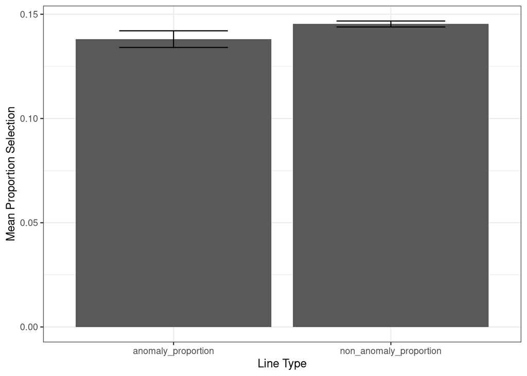

```r
out <- p_data
colnames(out)[3] <- 'proportion'
write.csv(ts, 'exp3_anomaly_participant_trial.csv', row.names = FALSE)
write.csv(out, 'exp3_anomaly_participant.csv', row.names = FALSE)

p_data %>%
  group_by(trial_type) %>%
  summarize(mean_proportion = mean(mp), se = sd(mp) / sqrt(N)) %>%
  print() %>%
  ggplot(aes(x = trial_type, y = mean_proportion)) +
  geom_bar(stat = 'identity') +
  geom_errorbar(aes(ymin = mean_proportion - se, ymax = mean_proportion + se), width = .5) +
  labs(
    x = 'Line Type',
    y = 'Mean Proportion Selection'
  ) +
  theme_bw()
```

```r
t.test(p_data[p_data$trial_type == 'anomaly_proportion',]$mp, p_data[p_data$trial_type == 'non_anomaly_proportion',]$mp, paired = TRUE)
```

```
##
##  Paired t-test
##
## data:  p_data[p_data$trial_type == "anomaly_proportion", ]$mp and p_data[p_data$trial_type == "non_anomaly_proportion", ]$mp
## t = -1.3634, df = 31, p-value = 0.1826
## alternative hypothesis: true difference in means is not equal to 0
## 95 percent confidence interval:
##  -0.018132873  0.003602919
## sample estimates:
## mean of the differences
##            -0.007264977
```

*Denominator for anomaly proportion.* Total non vertical, non exterior lines that are contiguous with anomaly grain *Denominator for non anomaly proportion.* Total selectable, non vertical lines in the array is 21, minus denominator for anomaly proportion

```r
write.csv(ts, 'trial_summary_anomaly.csv', row.names = FALSE)
write.csv(data.frame(column = colnames(ts)), 'trial_summary_column_key.csv', row.names = FALSE)
```

## Line Clicking

```r
library(tidyverse)
library(data.table)
library(ggridges)
d <- read.csv('../../data/exp3_long_data.csv')
thinnest_lines <- read.csv('../../data/exp3_thinnest_lines.csv')
if (!'accuracy_type' %in% colnames(d)) {
  source('../compute_accuracy_columns.r')
  d <- compute_accuracy_columns(d, thinnest_lines)

}

N <- length(unique(d$participant))
head(d)
```

|  | participant | date | overall_time | trial_count | click_order | prompt_rt_sec | selection_rt_ms | pressed_object | line_width | top_x | top_y | bottom_x | bottom_y | line_id | line_orientation | selected_or_released | accuracy | possible_thinnest_lines | is_practice | is_anomaly_trial | anomaly_mid_x | anomaly_mid_y | anomaly_line_id | anomaly_group | drop_marker | indecision_trial | accuracy_type |
| --- | --- | --- | --- | --- | --- | --- | --- | --- | --- | --- | --- | --- | --- | --- | --- | --- | --- | --- | --- | --- | --- | --- | --- | --- | --- | --- | --- |
| 1 | 59 | 2021_Oct_29_1030 | 0 days 00:03:50.701515000 | 0 | 1 | 20.14598 | 2257.722 | line | 1.3333 | -204.596567 | 280.00000 | -302.29828 | 210.3267 | r0c0_bottom_right | forward_slash | selected | NA | 5 | True | False | NA | NA |  | NA | 59_0 | 0 | hit |
| 2 | 59 | 2021_Oct_29_1030 | 0 days 00:03:52.335821000 | 0 | 2 | 20.14598 | 3892.028 | line | 1.3333 | -9.193134 | 280.00000 | 88.50858 | 210.3267 | r0c2_bottom_left | back_slash | selected | NA | 5 | True | False | NA | NA |  | NA | 59_0 | 0 | hit |
| 3 | 59 | 2021_Oct_29_1030 | 0 days 00:03:54.272049000 | 0 | 3 | 20.14598 | 5828.256 | line | 1.3333 | 186.210299 | -99.34668 | 283.91202 | -169.0200 | r2c3_bottom_left | back_slash | selected | NA | 5 | True | False | NA | NA |  | NA | 59_0 | 0 | hit |
| 4 | 59 | 2021_Oct_29_1030 | 0 days 00:03:57.777328000 | 0 | 4 | 20.14598 | 9333.535 | submit | NA | NA | NA | NA | NA |  |  |  | 1 | 5 | True | False | NA | NA |  | NA | 59_0 | 0 | NA |
| 5 | 59 | 2021_Oct_29_1030 | 0 days 00:04:56.334246000 | 1 | 1 | 21.06081 | 862.950 | line | 1.6667 | 186.210299 | -99.34668 | 283.91202 | -169.0200 | r2c3_bottom_left | back_slash | selected | NA | 5 | False | False | NA | NA |  | NA | 59_1 | 0 | hit |
| 6 | 59 | 2021_Oct_29_1030 | 0 days 00:04:57.102628000 | 1 | 2 | 21.06081 | 1631.332 | line | 1.6667 | 186.210299 | -99.34668 | 88.50858 | -169.0200 | r2c2_bottom_right | forward_slash | selected | NA | 5 | False | False | NA | NA |  | NA | 59_1 | 0 | hit |

```r
colnames(d)[which(colnames(d) == 'participant')] <- 'subject'

click_summary <- d %>%
  group_by(subject, trial_count) %>%
  summarize(count = n()) %>%
  filter(count == 4) %>%
  select(-count) %>%
  mutate(key = 'keep')
d <- d %>%
  inner_join(click_summary) %>%
  filter(key == 'keep', is.na(accuracy)) %>%
  select(-key)
d$selection_rt_ms_relative <- ifelse(shift(d$click_order) < d$click_order, d$selection_rt_ms - shift(d$selection_rt_ms), d$selection_rt_ms)
d$selection_rt_ms_relative[1] <- d$selection_rt_ms[1]
d$accuracy_numeric <- ifelse(d$accuracy_type == 'hit', 1, 0)

write.csv(d, 'exp3_trial_clicking.csv', row.names = FALSE)

subject_summary <- d %>%
  group_by(subject, click_order) %>%
  summarize(RT = mean(selection_rt_ms_relative), Accuracy = mean(accuracy_numeric))
```

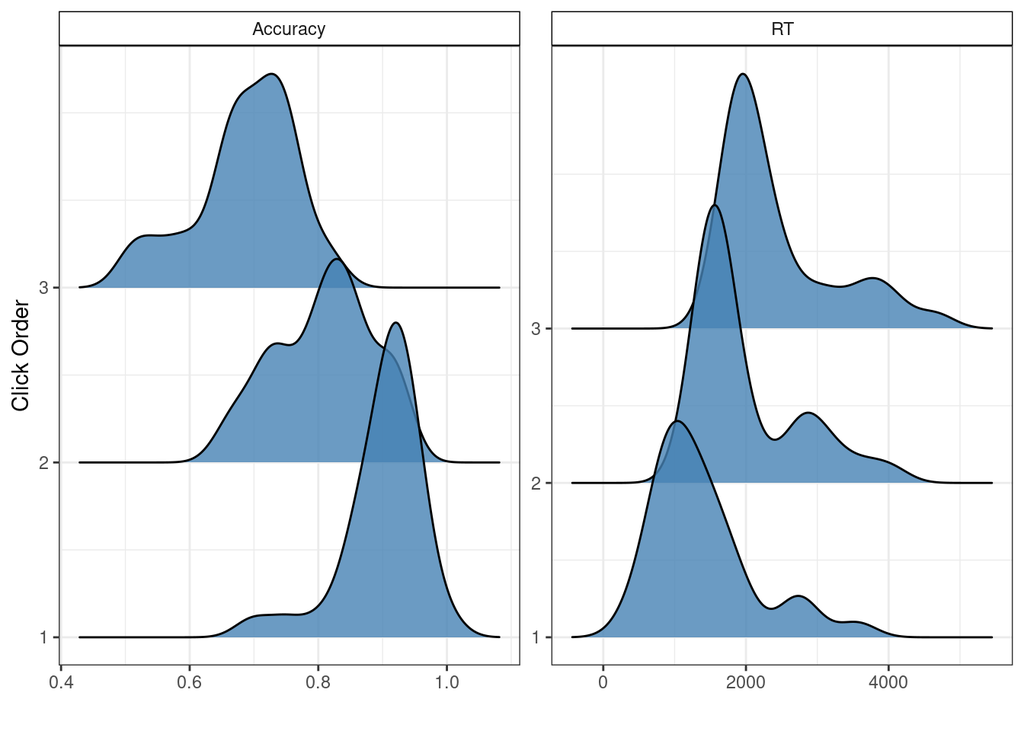

```r
write.csv(subject_summary, 'exp3_group_clicking.csv', row.names = FALSE)

subject_summary %>%
  gather(outcome, value, RT:Accuracy) %>%
  ggplot(aes(x = value, y = click_order, group = click_order)) +
  geom_density_ridges(fill = 'steel blue', alpha = .8) +
  facet_wrap(~outcome, scales = 'free') +
  labs(
    x = '',
    y = 'Click Order'
  ) +
  scale_y_continuous(breaks = 1:3) +
  theme_bw() +
  theme(strip.background = element_rect(color = 'black', fill = 'white'))
```

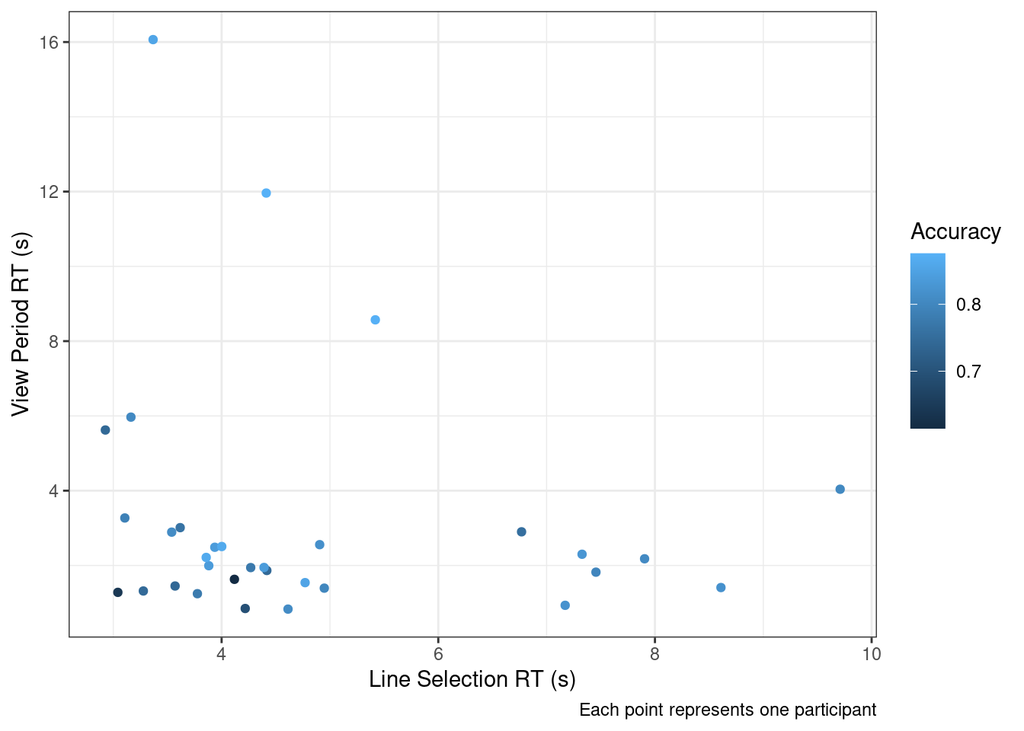

```r
## this computation includes in selection time the time it took them to press the submit button
## also im including line releases
d <- read.csv('../../data/exp3_long_data.csv')
colnames(d)[colnames(d) == 'participant'] <- 'subject'
out <- d %>%
  group_by(subject) %>%
  summarize(prompt_rt_sec = mean(prompt_rt_sec), selection_rt_ms = mean(selection_rt_ms), accuracy = mean(accuracy, na.rm = TRUE))

write.csv(out, 'exp3_individual_clicking.csv', row.names = FALSE)

out %>%
  ggplot(aes(x = selection_rt_ms/1000, y = prompt_rt_sec)) +
  geom_point(aes(color = accuracy)) +
  labs(
    x = 'Line Selection RT (s)',
    y = 'View Period RT (s)',
    color = 'Accuracy',
    caption = 'Each point represents one participant'
  ) +
  theme_bw()
```

```
## # A tibble: 6 × 3
##   quadrant mean_dprime     se
##   <chr>          <dbl>  <dbl>
## 1 I               1.59 0.0931
## 2 II              1.46 0.0847
## 3 III             1.81 0.157
## 4 IV              1.69 0.137
## 5 x_axis          1.51 0.0870
## 6 y_axis          1.53 0.113
```

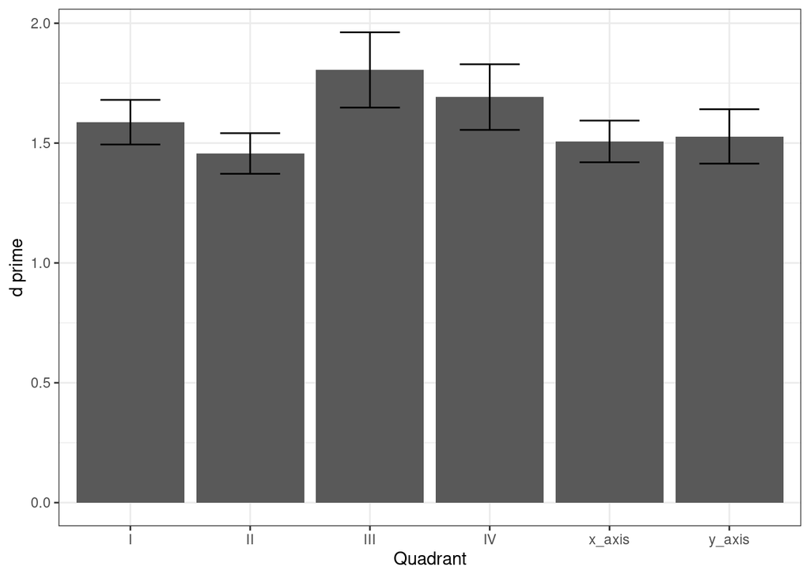

```r
source('../compute_quadrants.r')

d <- compute_quadrants(d, line_data)

colnames(d)[colnames(d) == 'subject'] <- 'participant'

d %>%
  filter(!(is.na(quadrant)), !(is.na(top_x)), !(is.na(accuracy_type)), line_orientation != 'vertical') %>%
  group_by(participant, quadrant, accuracy_type) %>%
  summarize(count = n()) %>%
  spread(accuracy_type, count) %>%
  mutate(hit_rate = hit / (hit + false_alarm)) %>%
  mutate(d_prime = qnorm(hit_rate) - qnorm(1 - hit_rate)) %>%
  group_by(quadrant) %>%
  summarize(mean_dprime = mean(d_prime, na.rm = TRUE), se = sd(d_prime, na.rm = TRUE) / sqrt(N)) %>%
  print() %>%
  ggplot(aes(x = quadrant, y = mean_dprime)) +
  geom_bar(stat = 'identity', position = position_dodge(width = .9)) +
  geom_errorbar(aes(ymin = mean_dprime - se, ymax = mean_dprime + se), width = .5, position = position_dodge(.9)) +
  labs(
    x = 'Quadrant',
    y = 'd prime'
  ) +
  theme_bw() +
  theme(legend.position = 'bottom')
```

A work by [Dave Braun](https://davebraun.net)

*dab414@lehigh.edu*